# Lab: Relational data in the tidyverse

Mark Huber

## Packages

The three packages needed for the lab today are:

- dplyr for joining data sets together,
- ggplot2 for a final visualization,
- nycflights13 for an illustration with a real dataset.

```r
library(dplyr)
library(ggplot2)
library(nycflights13)
```

# Relational Data

A dataset is in *relational form* if the dataset can be broken into tables, where each table has a set of column names, and each row of the table is an observation whose entries measure what is indicated in that column. Each table is also known as a *relation*.

This leads to the question of how to bring together observations from different tables when the two tables might have different columns (variables).

## Bringing data together

Start with a small toy data set that describes the band members of the Beatles and Rolling Stones. They are included as part of the package `dplyr`, so have already been loaded.

There are three tables to illustrate joining tables, `band_members`, `band_instruments`, and `band_instruments2`.

```r
band_members
```

```
## # A tibble: 3 × 2
##   name  band
##   <chr> <chr>
## 1 Mick  Stones
## 2 John  Beatles
## 3 Paul  Beatles
```

```r
band_instruments
```

```
## # A tibble: 3 × 2
##   name  plays
##   <chr> <chr>
## 1 John  guitar
## 2 Paul  bass
## 3 Keith guitar
```

```r
band_instruments2
```

```
## # A tibble: 3 × 2
##   artist plays
##   <chr>  <chr>
## 1 John   guitar
## 2 Paul   bass
## 3 Keith  guitar
```

Take a look at `band_members`. Recall that a *key* is a single variable or set of variables that once the values are known, the observation is known. Is the set $\{\text{band}\}$ a key? Assign your answer as either TRUE or FALSE to `answer01`.

```r
answer01 <- FALSE
```

In `band_members`, is $\{ \text{name} \}$ a key? Assign your answer as either TRUE or FALSE to `answer02`.

```r
answer02 <- TRUE
```

## Checking if a variable is a key

To double check your answers above, let’s count the number of times each value appears in each variable using the count function. First for the `name` variable.

```r
band_members |> count(name)
```

```
## # A tibble: 3 × 2
##   name      n
##   <chr> <int>
## 1 John      1
## 2 Mick      1
## 3 Paul      1
```

If `name` is a key, then each observation from `name` will only appear once.

Now for the `band` variable.

```r
band_members |> count(band)
```

```
## # A tibble: 2 × 2
##   band        n
##   <chr>   <int>
## 1 Beatles     2
## 2 Stones      1
```

If `band` is a key that uniquely determines the observation, then each entry from `band` will appear only once.

For a variable to be a key, what is the largest the variable `n` can be in the `count(variablename)` result? Put this integer into `answer03`.

```r
answer03 <- 1
```

## Mutating joins

A *mutating join* adds variables from one table to another. There are four types of such joins. Let’s try the four types of mutating joins with these tables.

First the *inner join*. This type of join brings observations that appear in both tables.

```r
band_members |> inner_join(band_instruments)
```

```
## # A tibble: 2 × 3
##   name  band    plays
##   <chr> <chr>   <chr>
## 1 John  Beatles guitar
## 2 Paul  Beatles bass
```

A *foreign key* is a key for observations from the second table.

What variable was used as the foreign key for `band_members`? Assign this as a string to `answer04`.

```r
answer04 <- 'name'
```

Note that the band member `"Keith"` was not included in the inner join. This is because Keith appears in `band_instruments`, but not in `band_members`.

What name appears in `band_members`, but not in `band_instruments` (and so does not show up in the inner join)? Assign this name as a string to `answer05`.

```r
answer05 <- 'Mick'
```

The next three joins are all types of *outer joins*. First the *left join* where every observation from the first table is included, and any information from the second table is added.

```r
band_members |> left_join(band_instruments)
```

```
## # A tibble: 3 × 3
##   name  band    plays
##   <chr> <chr>   <chr>
## 1 Mick  Stones  <NA>
## 2 John  Beatles guitar
## 3 Paul  Beatles bass
```

Between `band_instruments` and `band_members` there are four names. Which name was excluded from the left join? Assign this name as a string to `answer06`.

```r
answer06 <- 'Keith'
```

Next there is the rarely used right join where all the observations from the second table are included, and information from the first table is added as needed.

```r
band_members |> right_join(band_instruments)
```

```
## # A tibble: 3 × 3
##   name  band    plays
##   <chr> <chr>   <chr>
## 1 John  Beatles guitar
## 2 Paul  Beatles bass
## 3 Keith <NA>    guitar
```

Now try the full join (also called an outer join), which keeps all observations from all tables, filling in information whenever possible.

```r
band_members |> full_join(band_instruments)
```

```
## # A tibble: 4 × 3
##   name  band    plays
##   <chr> <chr>   <chr>
## 1 Mick  Stones  <NA>
## 2 John  Beatles guitar
## 3 Paul  Beatles bass
## 4 Keith <NA>    guitar
```

## Filtering joins

The *filtering joins* do not add variables to a table, rather, they select based on the presence or absence of the variable in the other table. For instance, consider the `semi_join`.

```r
band_members |> semi_join(band_instruments)
```

```
## # A tibble: 2 × 2
##   name  band
##   <chr> <chr>
## 1 John  Beatles
## 2 Paul  Beatles
```

Consider which table the `semi_join` output draws its variables from. If it was `band_instruments`, then use `answer07 <- band_instruments`. If it was `band_members`, then use `answer07 <- band_members`.

```r
answer07 <- band_members
```

The semi-join does not include the name Mick from variable `name` because that name does not appear in `band_instruments`.

Observations in the second table `band_instruments` that do not appear in the first will also not be a part of the semi-join. What name in `band_instruments` does not appear in `band_members`? Assign this name as a string to `answer08`.

```r
answer08 <- 'Keith'
```

The next type of filtering join is an *anti join*. Try this out:

```r
band_members |> anti_join(band_instruments)
```

```
## # A tibble: 1 × 2
##   name  band
##   <chr> <chr>
## 1 Mick  Stones
```

Which table, `band_members` or `band_instruments` would be the union of the `semi_join` and `anti_join` of the two tables? Assign your answer to `answer09`.

```r
answer09 <- band_members
```

### Changing variable names

Consider the `band_instruments2` table.

```r
band_instruments2
```

```
## # A tibble: 3 × 2
##   artist plays
##   <chr>  <chr>
## 1 John   guitar
## 2 Paul   bass
## 3 Keith  guitar
```

This table `band_instruments2` contains the same information as `band_instruments`, but the first variable name is now `artist` rather than `name`. To successfully use our joins on this table, we need to tell R what variables to use as the key.

```r
band_members |>
  full_join(band_instruments2,
            by = c("name" = "artist"))
```

```
## # A tibble: 4 × 3
##   name  band    plays
##   <chr> <chr>   <chr>
## 1 Mick  Stones  <NA>
## 2 John  Beatles guitar
## 3 Paul  Beatles bass
## 4 Keith <NA>    guitar
```

Suppose we had used `by = c("band" = "artist")` in the above command by mistake. How many missing values would appear in the result? Assign your integer answer to `answer10`.

```r
answer <- 6
```

## Working with non keys

The join functions will still run when keys are not used, but the output has many more rows. Because the functions will not know which value is the `right’ observation, it is forced to include all possibilities. Consider the following tables:

```r
t1 <- tibble(
  name = c('AZI-3', '2-1B', 'R2-Q5', 'AZI-3'),
  occupation = c('med', 'surgery', 'astromech', 'protocol')
  )
t2 <- tibble(
  name = c('AZI-3', 'R2-Q5'),
  location = c('Kamino', 'Death Star II')
  )
```

Now consider what happens when we use name to add location data to `t1`:

```r
t1 |> full_join(t2, by = "name")
```

[output not shown]

Note that `AZI-3` ends up appearing twice, once with occupation `"med"` and once with occupation `"protocol"`.

## Flights from the New York area

Now let’s try some of these ideas with a real data set.

One of the data tables in the `nycflights13` package is `weather`, which contains the temp, dew point, humidity, and wind_dir for each hour of every day in 2013 recorded at LGA (La Guardia Airport), JFK (John F. Kennedy Airport), and EWR (Newark Airport).

```r
weather |> head()
```

```
## # A tibble: 6 × 15
##   origin  year month   day  hour  temp  dewp humid wind_dir
##   <chr>  <int> <int> <int> <int> <dbl> <dbl> <dbl>    <dbl>
## 1 EWR     2013     1     1     1  39.0  26.1  59.4      270
## 2 EWR     2013     1     1     2  39.0  27.0  61.6      250
## 3 EWR     2013     1     1     3  39.0  28.0  64.4      240
## 4 EWR     2013     1     1     4  39.9  28.0  62.2      250
## 5 EWR     2013     1     1     5  39.0  28.0  64.4      260
## 6 EWR     2013     1     1     6  37.9  28.0  67.2      240
## # … with 6 more variables: wind_speed <dbl>, wind_gust <dbl>,
## #   precip <dbl>, pressure <dbl>, visib <dbl>,
## #   time_hour <dttm>
```

Another table `flights` contains all flights leaving LGA, JFK, and EWR.

```r
flights |> head()
```

```
## # A tibble: 6 × 19
##    year month   day dep_time sched_d…¹ dep_d…² arr_t…³ sched…⁴
##   <int> <int> <int>    <int>     <int>   <dbl>   <int>   <int>
## 1  2013     1     1      517       515       2     830     819
## 2  2013     1     1      533       529       4     850     830
## 3  2013     1     1      542       540       2     923     850
## 4  2013     1     1      544       545      -1    1004    1022
## 5  2013     1     1      554       600      -6     812     837
## 6  2013     1     1      554       558      -4     740     728
## # … with 11 more variables: arr_delay <dbl>, carrier <chr>,
## #   flight <int>, tailnum <chr>, origin <chr>, dest <chr>,
## #   air_time <dbl>, distance <dbl>, hour <dbl>, minute <dbl>,
## #   time_hour <dttm>, and abbreviated variable names
## #   ¹sched_dep_time, ²dep_delay, ³arr_time, ⁴sched_arr_time
```

By using a left join, the temperature at the time of flight can be added from the `weather` relation to the `flights` relation to get a new table `flightstemp`.

```r
flightstemp <-
  left_join(flights, weather)
```

Once the data is joined as a variable, it can be used like any other variable. For instance, the mean temperature of flights grouped by month can be found.

```r
flightstemp |>
  group_by(month) |>
  summarize(m = mean(temp, na.rm = TRUE))
```

```
## # A tibble: 12 × 2
##    month     m
##    <int> <dbl>
##  1     1  36.5
##  2     2  35.6
##  3     3  41.1
##  4     4  53.5
##  5     5  63.8
##  6     6  73.9
##  7     7  81.6
##  8     8  75.9
##  9     9  69.2
## 10    10  61.5
## 11    11  46.2
## 12    12  39.3
```

A bar chart can be used to visualize this data.

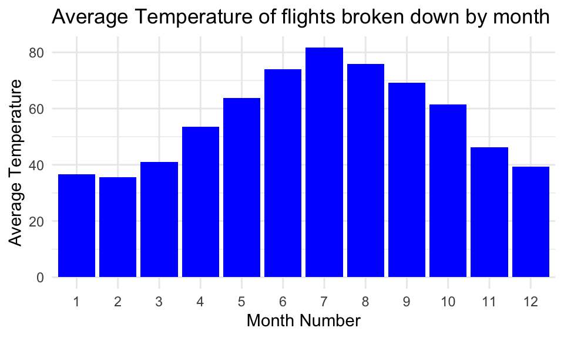

```r
flightstemp |>
  group_by(month) |>
  summarize(m = mean(temp, na.rm = TRUE)) |>
  ggplot(aes(x = factor(month), y = m)) +
  geom_bar(fill = "blue",
           stat = "identity") +
  xlab("Month Number") +
  ylab("Average Temperature") +
  theme_minimal() +
  ggtitle("Average Temperature of flights broken down by month")
```